# assessment_dsc_C4859681

## Model to determine if a given transaction is fraudulent or not

### ML -> Supervised Learning Problem -> Classification Problem

##### Flow

1. Data Loading  
   ↓
2. Transaction Analysis (Histogram & Box Plot)  
   ↓
3. Duplicate Transactions (Multi-swipe, Reversed)  
   ↓
4. Data Processing
   - Feature Engineering
   - Null Handling
   - Encoding
   - Downsampling (Class Imbalance)  
     ↓  
     Model Training
   - Logistic Regression
   - Random Forest
   - XGBoost
   - ANN  
     ↓  
     Model Evaluation (Precision, Recall, F1, AUC)  
     ↓  
     Model Selection (Best Performing Model)  
     ↓  
     Feature Importance  
     ↓  
     Conclusion

```python
## Core Libraries
import pandas as pd
import numpy as np
import matplotlib.pyplot as plt
import seaborn as sns

## Jupyter Extensions
%load_ext blackcellmagic

## Sklearn Preprocessing, Modeling, Pipelines
from sklearn.model_selection import train_test_split
from sklearn.preprocessing import StandardScaler, LabelEncoder, OneHotEncoder
from sklearn.impute import SimpleImputer
from sklearn.compose import ColumnTransformer
from sklearn.pipeline import Pipeline
from sklearn.linear_model import LogisticRegression
from sklearn.ensemble import RandomForestClassifier
from category_encoders import TargetEncoder
from sklearn.model_selection import GridSearchCV
from sklearn.model_selection import GridSearchCV
from sklearn.neural_network import MLPClassifier
from scikeras.wrappers import KerasClassifier
from sklearn.model_selection import GridSearchCV
from tensorflow.keras.models import Sequential
from tensorflow.keras.layers import Dense
from tensorflow.keras import regularizers
from tensorflow.keras.optimizers import Adam

## Imbalanced
from imblearn.over_sampling import SMOTE
from imblearn.pipeline import Pipeline as ImbPipeline
from imblearn.under_sampling import RandomUnderSampler

## XGBoost
from xgboost import XGBClassifier

## TensorFlow Keras
from tensorflow.keras.models import Sequential
from tensorflow.keras.layers import Dense

## Metric
from sklearn.metrics import f1_score, precision_score, recall_score, accuracy_score, confusion_matrix, roc_auc_score, roc_curve
import pickle
```

```
The blackcellmagic extension is already loaded. To reload it, use:
  %reload_ext blackcellmagic
```

#### 1. Load

##### 1.1 Loading data from directory

```python
## Function to load data from the directory
class Load:
    def load_data(self, file_path):
        data_load = pd.read_json(file_path, lines=True)
        return data_load
```

```python
load = Load()
path = "data/transactions.txt"
transaction_data = load.load_data(path)
transaction_data.replace("", np.nan, inplace=True)
transaction_data.head(10)
```

|  | accountNumber | customerId | creditLimit | availableMoney | transactionDateTime | transactionAmount | merchantName | acqCountry | merchantCountryCode | posEntryMode | ... | echoBuffer | currentBalance | merchantCity | merchantState | merchantZip | cardPresent | posOnPremises | recurringAuthInd | expirationDateKeyInMatch | isFraud |
| --- | --- | --- | --- | --- | --- | --- | --- | --- | --- | --- | --- | --- | --- | --- | --- | --- | --- | --- | --- | --- | --- |
| 0 | 737265056 | 737265056 | 5000 | 5000.00 | 2016-08-13T14:27:32 | 98.55 | Uber | US | US | 02 | ... | NaN | 0.00 | NaN | NaN | NaN | False | NaN | NaN | False | False |
| 1 | 737265056 | 737265056 | 5000 | 5000.00 | 2016-10-11T05:05:54 | 74.51 | AMC #191138 | US | US | 09 | ... | NaN | 0.00 | NaN | NaN | NaN | True | NaN | NaN | False | False |
| 2 | 737265056 | 737265056 | 5000 | 5000.00 | 2016-11-08T09:18:39 | 7.47 | Play Store | US | US | 09 | ... | NaN | 0.00 | NaN | NaN | NaN | False | NaN | NaN | False | False |
| 3 | 737265056 | 737265056 | 5000 | 5000.00 | 2016-12-10T02:14:50 | 7.47 | Play Store | US | US | 09 | ... | NaN | 0.00 | NaN | NaN | NaN | False | NaN | NaN | False | False |
| 4 | 830329091 | 830329091 | 5000 | 5000.00 | 2016-03-24T21:04:46 | 71.18 | Tim Hortons #947751 | US | US | 02 | ... | NaN | 0.00 | NaN | NaN | NaN | True | NaN | NaN | False | False |
| 5 | 830329091 | 830329091 | 5000 | 5000.00 | 2016-04-19T16:24:27 | 30.76 | In-N-Out #422833 | US | US | 02 | ... | NaN | 0.00 | NaN | NaN | NaN | True | NaN | NaN | False | False |
| 6 | 830329091 | 830329091 | 5000 | 5000.00 | 2016-05-21T14:50:35 | 57.28 | Krispy Kreme #685312 | US | US | 02 | ... | NaN | 0.00 | NaN | NaN | NaN | True | NaN | NaN | False | False |
| 7 | 830329091 | 830329091 | 5000 | 5000.00 | 2016-06-03T00:31:21 | 9.37 | Shake Shack #968081 | US | US | 05 | ... | NaN | 0.00 | NaN | NaN | NaN | True | NaN | NaN | False | False |
| 8 | 830329091 | 830329091 | 5000 | 4990.63 | 2016-06-10T01:21:46 | 523.67 | Burger King #486122 | NaN | US | 02 | ... | NaN | 9.37 | NaN | NaN | NaN | True | NaN | NaN | False | False |
| 9 | 830329091 | 830329091 | 5000 | 5000.00 | 2016-07-11T10:47:16 | 164.37 | Five Guys #510989 | US | US | 05 | ... | NaN | 0.00 | NaN | NaN | NaN | True | NaN | NaN | False | False |

10 rows × 29 columns

##### 1.2 Structure of Data - No. of rows and columns and data types of each column feature

```python
num_transactions, num_features = transaction_data.shape
print(f"Number of records :  {num_transactions}")
print(f"Number of fields :  {num_features}")
```

```
Number of records :  786363
Number of fields :  29
```

```python
## Data Types
transaction_data.dtypes
```

```
accountNumber                 int64
customerId                    int64
creditLimit                   int64
availableMoney              float64
transactionDateTime          object
transactionAmount           float64
merchantName                 object
acqCountry                   object
merchantCountryCode          object
posEntryMode                 object
posConditionCode             object
merchantCategoryCode         object
currentExpDate               object
accountOpenDate              object
dateOfLastAddressChange      object
cardCVV                       int64
enteredCVV                    int64
cardLast4Digits               int64
transactionType              object
echoBuffer                  float64
currentBalance              float64
merchantCity                float64
merchantState               float64
merchantZip                 float64
cardPresent                    bool
posOnPremises               float64
recurringAuthInd            float64
expirationDateKeyInMatch       bool
isFraud                        bool
dtype: object
```

```python
## Changing the data types of specific columns
date_columns = ["transactionDateTime", "accountOpenDate", "dateOfLastAddressChange"]
for col in date_columns:
    transaction_data[col] = pd.to_datetime(transaction_data[col], errors="coerce")
```

```python
data_stats = pd.DataFrame(
    {
        "data_type": transaction_data.dtypes,
        "null_count": transaction_data.isnull().sum(),
        "unique_count": transaction_data.nunique(),
    }
)

min_data = transaction_data.apply(
    lambda x: x.min()
    if np.issubdtype(x.dtype, np.number) or np.issubdtype(x.dtype, np.datetime64)
    else None
)
max_data = transaction_data.apply(
    lambda x: x.max()
    if np.issubdtype(x.dtype, np.number) or np.issubdtype(x.dtype, np.datetime64)
    else None
)

data_stats["min"] = min_data
data_stats["max"] = max_data

data_stats
```

|  | data_type | null_count | unique_count | min | max |
| --- | --- | --- | --- | --- | --- |
| accountNumber | int64 | 0 | 5000 | 100088067 | 999389635 |
| customerId | int64 | 0 | 5000 | 100088067 | 999389635 |
| creditLimit | int64 | 0 | 10 | 250 | 50000 |
| availableMoney | float64 | 0 | 521915 | -1005.63 | 50000.0 |
| transactionDateTime | datetime64[ns] | 0 | 776637 | 2016-01-01 00:01:02 | 2016-12-30 23:59:45 |
| transactionAmount | float64 | 0 | 66038 | 0.0 | 2011.54 |
| merchantName | object | 0 | 2490 | None | None |
| acqCountry | object | 4562 | 4 | None | None |
| merchantCountryCode | object | 724 | 4 | None | None |
| posEntryMode | object | 4054 | 5 | None | None |
| posConditionCode | object | 409 | 3 | None | None |
| merchantCategoryCode | object | 0 | 19 | None | None |
| currentExpDate | object | 0 | 165 | None | None |
| accountOpenDate | datetime64[ns] | 0 | 1820 | 1989-08-22 00:00:00 | 2015-12-31 00:00:00 |
| dateOfLastAddressChange | datetime64[ns] | 0 | 2184 | 1989-08-22 00:00:00 | 2016-12-30 00:00:00 |
| cardCVV | int64 | 0 | 899 | 100 | 998 |
| enteredCVV | int64 | 0 | 976 | 0 | 998 |
| cardLast4Digits | int64 | 0 | 5245 | 0 | 9998 |
| transactionType | object | 698 | 3 | None | None |
| echoBuffer | float64 | 786363 | 0 | NaN | NaN |
| currentBalance | float64 | 0 | 487318 | 0.0 | 47498.81 |
| merchantCity | float64 | 786363 | 0 | NaN | NaN |
| merchantState | float64 | 786363 | 0 | NaN | NaN |
| merchantZip | float64 | 786363 | 0 | NaN | NaN |
| cardPresent | bool | 0 | 2 | None | None |
| posOnPremises | float64 | 786363 | 0 | NaN | NaN |
| recurringAuthInd | float64 | 786363 | 0 | NaN | NaN |
| expirationDateKeyInMatch | bool | 0 | 2 | None | None |
| isFraud | bool | 0 | 2 | None | None |

```python
print("Fraud Transactions:", transaction_data["isFraud"].sum())
print("Non Fraud Transactions:", (~transaction_data["isFraud"]).sum())
```

```
Fraud Transactions: 12417
Non Fraud Transactions: 773946
```

##### 1.3 Observations from the data_stats

- Missing Data : Columns (like merchantCity, merchantState, merchantZip, and echoBuffer) have 786,363 nulls - Indicating incomplete information
- accountNumber and customerId have 5,000 unique values and share identical min and max values - Both field corresponds to same information
- isFraud contains the information about fradulent transaction - Data is highly imbalance

```python
## Statatistics of field with Numeric Data Type
transaction_data.describe(include="number")
```

|  | accountNumber | customerId | creditLimit | availableMoney | transactionAmount | cardCVV | enteredCVV | cardLast4Digits | echoBuffer | currentBalance | merchantCity | merchantState | merchantZip | posOnPremises | recurringAuthInd |
| --- | --- | --- | --- | --- | --- | --- | --- | --- | --- | --- | --- | --- | --- | --- | --- |
| count | 7.863630e+05 | 7.863630e+05 | 786363.000000 | 786363.000000 | 786363.000000 | 786363.000000 | 786363.000000 | 786363.000000 | 0.0 | 786363.000000 | 0.0 | 0.0 | 0.0 | 0.0 | 0.0 |
| mean | 5.372326e+08 | 5.372326e+08 | 10759.464459 | 6250.725369 | 136.985791 | 544.467338 | 544.183857 | 4757.417799 | NaN | 4508.739089 | NaN | NaN | NaN | NaN | NaN |
| std | 2.554211e+08 | 2.554211e+08 | 11636.174890 | 8880.783989 | 147.725569 | 261.524220 | 261.551254 | 2996.583810 | NaN | 6457.442068 | NaN | NaN | NaN | NaN | NaN |
| min | 1.000881e+08 | 1.000881e+08 | 250.000000 | -1005.630000 | 0.000000 | 100.000000 | 0.000000 | 0.000000 | NaN | 0.000000 | NaN | NaN | NaN | NaN | NaN |
| 25% | 3.301333e+08 | 3.301333e+08 | 5000.000000 | 1077.420000 | 33.650000 | 310.000000 | 310.000000 | 2178.000000 | NaN | 689.910000 | NaN | NaN | NaN | NaN | NaN |
| 50% | 5.074561e+08 | 5.074561e+08 | 7500.000000 | 3184.860000 | 87.900000 | 535.000000 | 535.000000 | 4733.000000 | NaN | 2451.760000 | NaN | NaN | NaN | NaN | NaN |
| 75% | 7.676200e+08 | 7.676200e+08 | 15000.000000 | 7500.000000 | 191.480000 | 785.000000 | 785.000000 | 7338.000000 | NaN | 5291.095000 | NaN | NaN | NaN | NaN | NaN |
| max | 9.993896e+08 | 9.993896e+08 | 50000.000000 | 50000.000000 | 2011.540000 | 998.000000 | 998.000000 | 9998.000000 | NaN | 47498.810000 | NaN | NaN | NaN | NaN | NaN |

##### Observations from the data_stats

- accountNumber and customerId have identical statistics - corresponds to same data
- creditLimit ranges from $250 to $50,000, with a mean of $10,759 - Indicates diverse customer risk profile
- Missing and Null values (echoBuffer, merchantCity, merchantState, etc) are completely null and can be removed from features during data processing for modeling

##### Summary - Load

Data has redundancy, missing values, and imbalance - requires cleaning and balancing before modeling

#### 2. Plot

```python
class Plots:
    def transaction_histogram(self, transaction_data):
        ## Histogram
        plt.figure(figsize=(8, 4))
        sns.histplot(
            transaction_data["transactionAmount"], bins=50, kde=True, color="blue"
        )
        ## Labels
        plt.title("Histogram of Transaction Amounts")
        plt.xlabel("Transaction Amount ($)")
        plt.ylabel("Frequency")
        plt.show()
    def transaction_boxplot(self, transaction_data):
        ## Box Plot
        plt.figure(figsize=(8, 2))
        sns.boxplot(
            x=transaction_data["transactionAmount"],
            color="green"
        )
        ## Labels
        plt.title("Box Plot of Transaction Amounts")
        plt.xlabel("Transaction Amount ($)")
        plt.show()
```

##### 2.1 Histogram - Transaction Amount

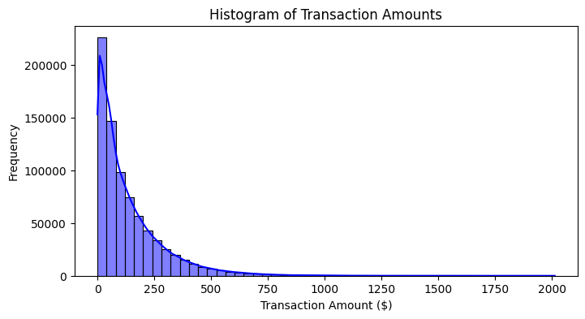

```python
histogram = Plots()
histogram.transaction_histogram(transaction_data)
```

Histogram

- Highly right skewed with most transaction being small ($0-$200) and few exceeding $500
- Peak at $0 indicating (possible refunds or authorizations)

##### Boxplot- Transaction Amount

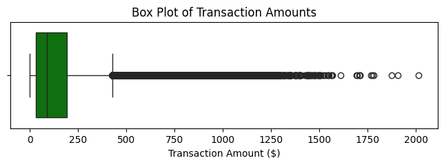

```python
boxplot = Plots()
histogram.transaction_boxplot(transaction_data)
```

Box Plot

- Most transcation in raneg $0-$200
- Long tail upto $2000 (Confirms skewness)
- Worth investigating transaction > $1000 for potential fraud

```python
mean = transaction_data["transactionAmount"].mean()
median = transaction_data["transactionAmount"].median()
mode = transaction_data["transactionAmount"].mode()[0]

print("Mean :", mean)
print("Median :", median)
print("Mode :", mode)
```

```
Mean : 136.98579095150708
Median : 87.9
Mode : 0.0
```

##### 2.2 Hypothesis from Transactions details

- The data is Heavily right - skewed (Mean > Median > Mode)
- Most Transactions are between $0- $200 and tail stretching up to $2000
- Highest peak frequency in range $0-$50 (Most transactions are low value corresponds to transactions related to day-to-day need like grocessory, cabs, transporation, etc)
- Outlier : Few transactions > $1000, may represent the expensive purchases or could also be fraud transaction (worth investigation)

#### 3. Data Wrangling

##### 3.1 Reverse Transaction and Multi-Swipe Transactions

```python
class DuplicateTransaction:
    def reverse_transactions(self, transaction_data, tz):
        purchase_transaction = transaction_data[
            transaction_data["transactionType"] == "PURCHASE"
        ]
        reversal_transaction = transaction_data[
            transaction_data["transactionType"] == "REVERSAL"
        ]
        reverse_df = reversal_transaction.merge(
            purchase_transaction,
            on=["accountNumber", "customerId", "transactionAmount", "merchantName"],
            suffixes=("_reversal", "_purchase"),
        )
        ## Assumtion that reversal will be considered (5 minutes)
        reverse_df = reverse_df[
            abs(
                reverse_df["transactionDateTime_reversal"]
                - reverse_df["transactionDateTime_purchase"]
            )
            < pd.Timedelta(minutes=tz)
        ]
        return reverse_df

    def multiswipe_transactions(self, transaction_data, tz):
        purchase_transaction = transaction_data[
            transaction_data["transactionType"] == "PURCHASE"
        ]
        purchase_transaction = purchase_transaction.sort_values(
            by=[
                "accountNumber",
                "merchantName",
                "transactionAmount",
                "transactionDateTime",
            ]
        )
        purchase_transaction["prev_time"] = purchase_transaction.groupby(
            ["accountNumber", "merchantName", "transactionAmount"]
        )["transactionDateTime"].shift(1)
        purchase_transaction["time_diff"] = (
            purchase_transaction["transactionDateTime"]
            - purchase_transaction["prev_time"]
        ).dt.total_seconds()

        ## Short-time spam assumed to be less than equal to 1 minutes (60 seconds)
        multi_swipe_df = purchase_transaction[
            purchase_transaction["time_diff"] <= tz * 60
        ]
        return multi_swipe_df


duplicate = DuplicateTransaction()
reverse_df = duplicate.reverse_transactions(transaction_data, 5)
num_reverse = len(reverse_df)
sum_reverse_transaction = reverse_df["transactionAmount"].sum()

multi_swipe_df = duplicate.multiswipe_transactions(transaction_data, 1)
num_multiswipe = len(multi_swipe_df)
sum_multiswipe_transaction = multi_swipe_df["transactionAmount"].sum()
```

##### 3.2 Total number of Reverse Transaction and Multi-Swipe Transactions

```python
print('Number of Revered Transactions:', num_reverse)
print('Total Dollar amount ($) from Reversed Transaction:', round(sum_reverse_transaction,2))
print('Number of Multi-Swipe Transactions:', num_multiswipe)
print('Total Dollar amount ($) from Multiswipe Transaction:', round(sum_multiswipe_transaction,2))
```

```
Number of Revered Transactions: 5619
Total Dollar amount ($) from Reversed Transaction: 840548.67
Number of Multi-Swipe Transactions: 2473
Total Dollar amount ($) from Multiswipe Transaction: 377419.84
```

##### 3.3 Insights and Analysis

##### Top Merchants

```python
## Top 20 Merchants for Reversal
reverse_merchant_counts = reverse_df['merchantName'].value_counts().head(20)
print(reverse_merchant_counts)
```

```
merchantName
Lyft                             204
Uber                             199
apple.com                        146
oldnavy.com                      140
gap.com                          139
staples.com                      138
amazon.com                       137
alibaba.com                      137
cheapfast.com                    132
sears.com                        130
target.com                       124
ebay.com                         122
walmart.com                      119
discount.com                     113
Fresh eCards                      69
Mobile eCards                     68
Next Day eCards                   62
Blue Mountain Online Services     62
Fresh Flowers                     61
Next Day Online Services          61
Name: count, dtype: int64
```

```python
## Top 20 Merchants for Multi Swipe
multi_swipe_merchant_counts = multi_swipe_df['merchantName'].value_counts().head(20)
print(multi_swipe_merchant_counts)
```

```
merchantName
Uber                             93
Lyft                             75
amazon.com                       63
oldnavy.com                      63
staples.com                      62
sears.com                        61
ebay.com                         61
apple.com                        58
alibaba.com                      58
gap.com                          57
cheapfast.com                    56
discount.com                     56
target.com                       48
walmart.com                      41
Next Day eCards                  36
Mobile eCards                    34
Fresh Online Services            34
Blue Mountain Online Services    29
Blue Mountain eCards             29
Fresh Flowers                    26
Name: count, dtype: int64
```

##### Merchant Analysis

Most of the purchases that are Multiswipe and reversal are usually the done for a online platforms. Where the cab services like Uber abd Lyft account for the hightest

##### Top Customers

```python
multi_swipe_df['customerId'].value_counts().head(20)
```

```
customerId
380680241    117
882815134     43
570884863     40
894938833     30
369308035     28
208319653     23
246251253     23
724518977     21
410523603     20
419709514     19
832842201     19
442799740     18
767620004     17
307632490     16
474934734     14
700725639     14
413425884     13
379443741     12
225678947     12
269616174     11
Name: count, dtype: int64
```

```python
reverse_df['customerId'].value_counts().head(20)
```

```
customerId
380680241    253
882815134    115
570884863     89
246251253     76
832842201     56
724518977     55
369308035     48
894938833     48
419709514     47
682319827     37
474934734     35
410523603     35
269616174     33
442799740     31
409705516     31
151580474     30
208319653     30
248663206     29
767620004     28
700725639     27
Name: count, dtype: int64
```

##### Customer Analysis

The most purchases occurances of Multiswipe and reversal done in case of customer with customer ID 380680241 and 882815134. It will be worth investigating further and keep track of transactions from these customers

##### Fraud Cases

```python
multi_swipe_df['isFraud'].value_counts().head(20)
```

```
isFraud
False    2425
True       48
Name: count, dtype: int64
```

```python
reverse_df['isFraud_purchase'].value_counts().head(20)
```

```
isFraud_purchase
False    5517
True      102
Name: count, dtype: int64
```

##### Fraud Analysis

Most of the Multiswipe and reversal transactions are genuine and not fraud

```python
merged_multi_reverse = pd.merge(
    multi_swipe_df,
    reverse_df,
    on=["customerId", "merchantName", "transactionAmount"],
    how="inner",
)
print(
    "Number of transactions where a multi swipe was reported after reversal:",
    len(merged_multi_reverse),
)
```

```
Number of transactions where a multi swipe was reported after reversal: 51
```

#### Insights from Multiswipe & Reverse Transactions

Reversed and multi-swipe transactions are frequent but typically non-fraudulent. However:

- Certain merchants and customers are outliers in frequency and requires monitoring
- Fraud rates, though low, are not negligible among multi-swipes, making them a good candidate for rule-based flagging in real-time systems.
- The overall $1.2M+ total dollar amount involved in such duplicates highlights the importance of proactive mitigation.

```python
multi_swipe_all = multi_swipe_df.index
reverse_false = reverse_df[reverse_df['isFraud_purchase']== False].index
to_remove_index = multi_swipe_all.union(reverse_false)
```

```python
transaction_df = transaction_data.drop(index=to_remove_index)
```

##### Removing redundant transaction data (Multi swipe and reverse)

- Multi-swipe transactions include repeated transactions (beyond the first within a short time window)- Including these in the dataset may introduce noise or bias the model. Therefore, are excluded from modeling
- Given the severe class imbalance (many more non-fraudulent transactions), we apply random undersampling on the isFraud = False class. To further reduce redundancy and improve signal clarity, we also remove reversal transactions where isFraud == False, as they are not informative for fraud detection.

#### 4. Model

##### Data Preprocessing

```python
df_data = transaction_df.copy()

## Time related feature
df_data["hour"] = df_data["transactionDateTime"].dt.hour
df_data["dayofweek"] = df_data["transactionDateTime"].dt.dayofweek
df_data["day"] = df_data["transactionDateTime"].dt.day
df_data["is_weekend"] = df_data["dayofweek"].isin([5, 6]).astype(int)

# Account Age
df_data["accountAgeDays"] = (
    df_data["transactionDateTime"] - df_data["accountOpenDate"]
).dt.days
df_data["daysSinceAddressChange"] = (
    df_data["transactionDateTime"] - df_data["dateOfLastAddressChange"]
).dt.days

# Bolean Feauture
df_data["cvv_mismatch"] = (df_data["cardCVV"] != df_data["enteredCVV"]).astype(int)
df_data["isCardPresent"] = df_data["cardPresent"].astype(int)
df_data["isExpMatch"] = df_data["expirationDateKeyInMatch"].astype(int)
df_data["cardPresent"] = df_data["cardPresent"].astype(int)
df_data["isFraud"] = df_data["isFraud"].astype(int)

## Drop redundant columns
## accountNumber <-> customerId : We can use either one of them
drop_columns = [
    "accountNumber",
    "transactionDateTime",
    "accountOpenDate",
    "dateOfLastAddressChange",
    "cardCVV",
    "enteredCVV",
    "cardLast4Digits",
    "echoBuffer",
    "expirationDateKeyInMatch",
    "merchantCity",
    "merchantState",
    "merchantZip",
    "posOnPremises",
    "recurringAuthInd",
]


df_data = df_data.drop(columns=drop_columns, errors="ignore")
```

```python
df_data_stats = pd.DataFrame(
    {
        "data_type": df_data.dtypes,
        "null_count": df_data.isnull().sum(),
        "unique_count": df_data.nunique(),
    }
)
df_data_stats
```

|  | data_type | null_count | unique_count |
| --- | --- | --- | --- |
| customerId | int64 | 0 | 5000 |
| creditLimit | int64 | 0 | 10 |
| availableMoney | float64 | 0 | 518205 |
| transactionAmount | float64 | 0 | 65944 |
| merchantName | object | 0 | 2490 |
| acqCountry | object | 4523 | 4 |
| merchantCountryCode | object | 720 | 4 |
| posEntryMode | object | 4005 | 5 |
| posConditionCode | object | 403 | 3 |
| merchantCategoryCode | object | 0 | 19 |
| currentExpDate | object | 0 | 165 |
| transactionType | object | 695 | 3 |
| currentBalance | float64 | 0 | 484394 |
| cardPresent | int64 | 0 | 2 |
| isFraud | int64 | 0 | 2 |
| hour | int32 | 0 | 24 |
| dayofweek | int32 | 0 | 7 |
| day | int32 | 0 | 31 |
| is_weekend | int64 | 0 | 2 |
| accountAgeDays | int64 | 0 | 5100 |
| daysSinceAddressChange | int64 | 0 | 4807 |
| cvv_mismatch | int64 | 0 | 2 |
| isCardPresent | int64 | 0 | 2 |
| isExpMatch | int64 | 0 | 2 |

```python
df_data_stats = df_data_stats[df_data_stats.index != "isFraud"]
numerical_columns = df_data.select_dtypes(
    include=["int64", "int32", "float64"]
).columns.tolist()
numerical_columns.remove("customerId")
categorical_columns = df_data_stats[
    df_data_stats["data_type"] == "object"
].index.tolist()
high_cardinality_columns = df_data_stats.loc[categorical_columns]
high_cardinality_columns = high_cardinality_columns[
    high_cardinality_columns["unique_count"] > 10
].index.tolist()
high_cardinality_columns.append("customerId")
low_cardinality_columns = [
    col for col in categorical_columns if col not in high_cardinality_columns
]

all_selected = numerical_columns + high_cardinality_columns + low_cardinality_columns
print("Selected final coulmns:", all_selected)
print("length of selected final coulmns:", len(all_selected))
```

[output not shown]

Transformation to be performed

- Null values to be replaced by most frequent
- Numerical columns to be scaled using Standard Scaler
- High cardinality columns to be encoded using Target Encoding
- Categorical columns to be encoded using One Hot Encoding
- Downsampling for handling Data Inbalance

```python
# Split features and target
y = df_data["isFraud"]
X = df_data.drop(columns=["isFraud"])

numerical_columns = [col for col in numerical_columns if col in X.columns]
high_cardinality_columns = [col for col in high_cardinality_columns if col in X.columns]
low_cardinality_columns = [col for col in low_cardinality_columns if col in X.columns]
## preprocessing pipelines
numerical_pipeline = Pipeline(
    steps=[
        ("imputer", SimpleImputer(strategy="most_frequent")),
        ("scaler", StandardScaler()),
    ]
)

high_card_pipeline = Pipeline(
    steps=[
        ("imputer", SimpleImputer(strategy="most_frequent")),
        ("target_encoder", TargetEncoder()),
    ]
)

low_card_pipeline = Pipeline(
    steps=[
        ("imputer", SimpleImputer(strategy="most_frequent")),
        ("onehot", OneHotEncoder(handle_unknown="ignore", sparse_output=False)),
    ]
)

## ColumnTransformer
preprocessor = ColumnTransformer(
    transformers=[
        ("num", numerical_pipeline, numerical_columns),
        ("high_card_cat", high_card_pipeline, high_cardinality_columns),
        ("low_card_cat", low_card_pipeline, low_cardinality_columns),
    ]
)

X_preprocessed = preprocessor.fit_transform(X, y)

with open("pickle_files/preprocessing_pipeline.pkl", "wb") as f:
    pickle.dump(preprocessor, f)

print("Before undersampling:")
print("X shape:", X_preprocessed.shape)
print("y distribution:", y.value_counts())

## Undersample - handling Imbalance
undersample = RandomUnderSampler(sampling_strategy="auto", random_state=42)
X_resampled, y_resampled = undersample.fit_resample(X_preprocessed, y)

print("\nAfter undersampling:")
print("X shape:", X_resampled.shape)
print("y distribution:", pd.Series(y_resampled).value_counts())
```

```
Before undersampling:
X shape: (778391, 37)
y distribution: isFraud
0    766107
1     12284
Name: count, dtype: int64

After undersampling:
X shape: (24568, 37)
y distribution: isFraud
0    12284
1    12284
Name: count, dtype: int64
```

##### Data Processing pipeline

- Pipeline: Scaled numericals, encoded categoricals (high_cardinality, low_cardinality)
- Balance Dataset : Random undersampling to handle fraud and non-fradulant transaction
- Saving processing pipeline as pickle file for future use

```python
def evaluate_model(model, X_test, y_test, plot, model_name, threshold):
    if model_name == "ANN":
        y_prob = model.predict(X_test).flatten()
    else:
        y_prob = model.predict_proba(X_test)[:, 1]

    y_pred = (y_prob >= threshold).astype(int)
    f1 = f1_score(y_test, y_pred)
    precision = precision_score(y_test, y_pred)
    recall = recall_score(y_test, y_pred)
    accuracy = accuracy_score(y_test, y_pred)
    auc = roc_auc_score(y_test, y_prob)
    cm = confusion_matrix(y_test, y_pred)

    res = {
        "F1 Score": round(f1, 2),
        "Precision": round(precision, 2),
        "Recall": round(recall, 2),
        "Accuracy": round(accuracy, 2),
        "AUC-ROC": round(auc, 2),
    }
    res_df = pd.DataFrame([res])

    ## Confusion - Matrix
    if plot:
        print(f"Confusion Matrix with {threshold}")
        sns.heatmap(cm, annot=True, fmt="d", cmap="Blues")
        plt.title(f"Confusion Matrix - {model_name}")
        plt.show()

        ## AUC-ROC
        print("\nAUC-ROC Curve")
        fpr, tpr, _ = roc_curve(y_test, y_prob)
        plt.plot(fpr, tpr, label=f"AUC {model_name} = {auc:.2f}")
        plt.plot([0, 1], [0, 1], "k--")
        plt.xlabel("False Positive Rate")
        plt.ylabel("True Positive Rate")
        plt.title(f"ROC Curve - {model_name}")
        plt.legend()
        plt.grid(True)
        plt.show()

    print(res_df)
    return res_df, res, fpr, tpr, auc, threshold
```

```python
# Train-Test Split
X_train, X_test, y_train, y_test = train_test_split(
    X_resampled, y_resampled, test_size=0.2, random_state=42
)
print("Shape of Train")
print("Shape of X_train:", np.shape(X_train))
print("Shape of y_train:", np.shape(y_train))
print("\nShape of Test")
print("Shape of X_test:", np.shape(X_test))
print("Shape of y_test:", np.shape(y_test))
```

```
Shape of Train
Shape of X_train: (19654, 37)
Shape of y_train: (19654,)

Shape of Test
Shape of X_test: (4914, 37)
Shape of y_test: (4914,)
```

The increase in features due to (One Hot encoding and target encoding of categorical features)

#### Modeling Approach (Model Traing , Evaluation and Comparison)

- The analysis will be performed on 4 ML models - Logistic Rgression, Random Forest, XGBoost, ANN
- For each of the model the best paramaters will be obtained using grid search CV
- Metric - F1 Score, Precision, Recall and AUC-ROC will be compared for deciding on the best model
- Additionally, Since the data was imbannce and handled using downsampling- it will be intersting to observe the behavior on varing the threshold (0.5, 0.4 and 0.6 resp.)
- Finally, based on the metric for each case the final model for a specific threshold will be chose and feature importance will be evaluated to decide on most import feature

Threshold = 0.5

```python
all_metrics = []
auc_data = []
```

##### Logistic Regression - Baseline

```python
def train_logistic_regression(X_train, y_train):
    param_grid = {"C": [0.01, 0.1, 1, 10], "penalty": ["l2"], "solver": ["lbfgs"]}
    grid = GridSearchCV(
        LogisticRegression(max_iter=1000), param_grid, scoring="f1", cv=3
    )
    grid.fit(X_train, y_train)
    print("Best Params for Logistic Regression:", grid.best_params_)
    return grid.best_estimator_
```

```python
def run_logi(threshold):
    logistic_model = train_logistic_regression(X_train, y_train)
    lg_df, lg_res, lg_fpr, lg_tpr, lg_auc, threshold = evaluate_model(
        logistic_model, X_test, y_test, plot=True, model_name="Logistic Regression", threshold = threshold
    )
    all_metrics.append(lg_res)
    auc_data.append((lg_fpr, lg_tpr, lg_auc))
    lg_df
    ## Save the model
    with open(f"pickle_files/{threshold}_logistic_model.pkl", "wb") as f:
        pickle.dump(logistic_model, f)
```

```
Best Params for Logistic Regression: {'C': 10, 'penalty': 'l2', 'solver': 'lbfgs'}
Confusion Matrix with 0.5
```

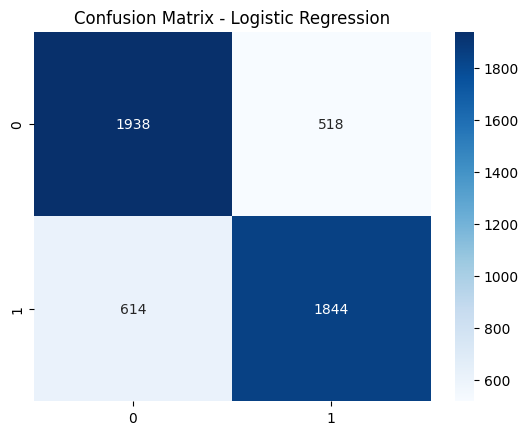

```
AUC-ROC Curve
```

```
   F1 Score  Precision  Recall  Accuracy  AUC-ROC
0      0.77       0.78    0.75      0.77     0.85
```

```python
run_logi(threshold=0.5)
```

[output not shown]

Obserations : Logistic Regression

- Performance : model has good accuracy (77%) with balanced precision (0.78) and recall (0.75) - handling minimizing false positive and false neagtive
- AUC ROC 0.85 - Model can distinguish well between 2 classes
- Limitation: Logistic Regression is not able to capture Non-linear relationship, it will be intresting to see the performance in ensemble models

##### Random Forest

```python
def train_random_forest(X_train, y_train):
    param_grid = {
        "n_estimators": [100, 200],
        "max_depth": [5, 10, None],
        "min_samples_split": [2, 5],
    }
    grid = GridSearchCV(RandomForestClassifier(), param_grid, scoring="f1", cv=3)
    grid.fit(X_train, y_train)
    print("Best Params for Random Forest", grid.best_params_)
    return grid.best_estimator_
```

```python
def run_rf(threshold):
    rf_model = train_random_forest(X_train, y_train)
    rf_df, rf_res, rf_fpr, rf_tpr, rf_auc, threshold  = evaluate_model(rf_model, X_test, y_test, plot = True, model_name= "Random Forest", threshold= threshold)
    all_metrics.append(rf_res)
    auc_data.append((rf_fpr, rf_tpr, rf_auc))
    rf_df
    ## Save the model
    with open(f"pickle_files/{threshold}_random_forest_model.pkl", "wb") as f:
        pickle.dump(rf_model, f)
```

```
Best Params for Random Forest {'max_depth': 10, 'min_samples_split': 5, 'n_estimators': 200}
Confusion Matrix with 0.5
```

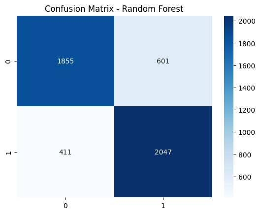

```
AUC-ROC Curve
```

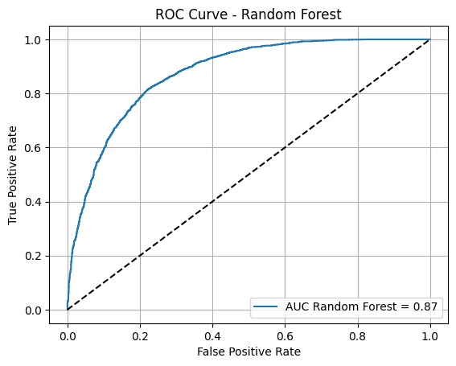

```
   F1 Score  Precision  Recall  Accuracy  AUC-ROC
0       0.8       0.77    0.83      0.79     0.87
```

```python
run_rf(0.5)
```

Random Forest: based on bagging ensemble model where, weak learners are trained parallely, works great in capturing complex non-linear relationship

- Performance : Model has (79%) accuracy with a precision (0.77) and recall (0.83) - This will be better than Logistic regression priotizing false negative as well as balancing on minizing False positive
- F1 = 0.8, good metric for evealuation for imbalance dataset
- AUC ROC 0.87 - Model can distinguish well between 2 classes
- overall, model performs better than Logistic Regression
- Strength : Priortizes reducing False negative while maintaing resonable false positive

#### XgBoost

```python
def train_xgboost(X_train, y_train):
    param_grid = {
        "n_estimators": [100, 200],
        "max_depth": [3, 6],
        "learning_rate": [0.01, 0.1],
        "subsample": [0.8, 1],
    }
    grid = GridSearchCV(
        XGBClassifier(use_label_encoder=False, eval_metric="logloss"),
        param_grid,
        scoring="f1",
        cv=3,
    )
    grid.fit(X_train, y_train)
    print("Best Params for XG-Boost", grid.best_params_)
    return grid.best_estimator_
```

```python
def run_xg(threshold):
    xg_model = train_xgboost(X_train, y_train)
    xg_df, xg_res, xg_fpr, xg_tpr, xg_auc, threshold = evaluate_model(
        xg_model, X_test, y_test, plot=True, model_name="XG-Boost", threshold = threshold
    )
    all_metrics.append(xg_res)
    auc_data.append((xg_fpr, xg_tpr, xg_auc))
    xg_df
    ## Save the model
    with open(f"pickle_files/{threshold}_xgboost_model.pkl", "wb") as f:
        pickle.dump(xg_model, f)
```

[output not shown]

[output cut: 137 more lines]

[output not shown]

```
Best Params for XG-Boost {'learning_rate': 0.1, 'max_depth': 3, 'n_estimators': 100, 'subsample': 0.8}
Confusion Matrix with 0.5
```

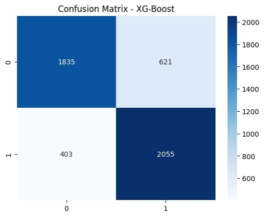

```
AUC-ROC Curve
```

```
   F1 Score  Precision  Recall  Accuracy  AUC-ROC
0       0.8       0.77    0.84      0.79     0.87
```

```python
run_xg(0.5)
```

[output not shown]

XGboost: based on boosting ensemble model where, weak learners are trained sequentially, works great in capturing complex non-linear relationship

- Performance : Model has (79%) accuracy with a precision (0.77) and recall (0.84) - better than logistic regression and similar in terms of performance as Random Forest, priotizing false negative as well as balancing on minizing False positive
- F1 = 0.8, good metric for evealuation for imbalance dataset
- AUC ROC 0.87 - Model can distinguish well between 2 classes
- overall, model has similar performance as Random Forest and better than Logistic Regression

##### ANN

```python
def create_ann(hidden_layer_sizes=(64,), alpha=0.0001, learning_rate_init=0.001):
    model = Sequential()
    model.add(
        Dense(
            hidden_layer_sizes[0],
            input_shape=(X_train.shape[1],),
            activation="relu",
            kernel_regularizer=regularizers.l2(alpha),
        )
    )

    for units in hidden_layer_sizes[1:]:
        model.add(
            Dense(units, activation="relu", kernel_regularizer=regularizers.l2(alpha))
        )

    model.add(Dense(1, activation="sigmoid"))

    optimizer = Adam(learning_rate=learning_rate_init)
    model.compile(optimizer=optimizer, loss="binary_crossentropy", metrics=["accuracy"])
    return model


def train_ann(X_train, y_train):
    model = KerasClassifier(model=create_ann, verbose=0)

    param_grid = {
        "model__hidden_layer_sizes": [(64,), (128,), (64, 32), (16, 32, 32)],
        "model__alpha": [0.0001, 0.001],
        "model__learning_rate_init": [0.001, 0.01],
        "batch_size": [32],
        "epochs": [100],
    }

    grid = GridSearchCV(
        estimator=model, param_grid=param_grid, scoring="f1", cv=3, n_jobs=-1, verbose=2
    )
    grid.fit(X_train, y_train)

    print("Best Params ANN:", grid.best_params_)
    return grid.best_estimator_.model_
```

```python
def run_ann(threshold):
    ann_model = train_ann(X_train, y_train)
    ann_df, ann_res, ann_fpr, ann_tpr, ann_auc, threshold = evaluate_model(
        ann_model, X_test, y_test, plot=True, model_name="ANN", threshold = threshold
    )
    all_metrics.append(ann_res)
    auc_data.append((ann_fpr, ann_tpr, ann_auc))
    ann_df
    ## Save the model
    with open(f"pickle_files/{threshold}_ann_model.pkl", "wb") as f:
        pickle.dump(ann_model, f)
```

```
Fitting 3 folds for each of 16 candidates, totalling 48 fits
```

[output not shown]

[output not shown]

[output not shown]

[output not shown]

[output not shown]

[output not shown]

[output not shown]

[output not shown]

[output not shown]

[output not shown]

[output not shown]

[output not shown]

[output not shown]

[output not shown]

[output not shown]

[output not shown]

[output not shown]

[output not shown]

[output not shown]

[output not shown]

[output not shown]

[output not shown]

[output not shown]

[output not shown]

[output not shown]

[output not shown]

[output not shown]

[output not shown]

[output not shown]

[output not shown]

```
Best Params ANN: {'batch_size': 32, 'epochs': 100, 'model__alpha': 0.001, 'model__hidden_layer_sizes': (64, 32), 'model__learning_rate_init': 0.001}
154/154 ━━━━━━━━━━━━━━━━━━━━ 0s 393us/step
Confusion Matrix with 0.5
```

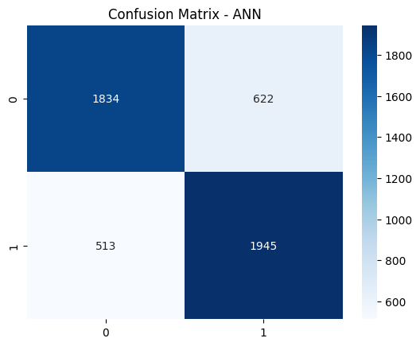

```
AUC-ROC Curve
```

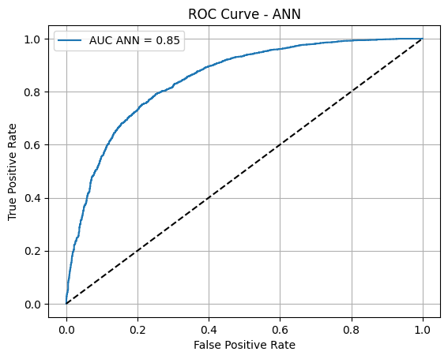

```
   F1 Score  Precision  Recall  Accuracy  AUC-ROC
0      0.77       0.76    0.79      0.77     0.85
```

```python
run_ann(threshold= 0.5)
```

##### ANN : A deep learning model based on no. of neurons and hidden layers to capture the non-linear complex relationship

- Performance : Model has (77%) accuracy with a precision (0.76) and recall (0.79) - Ensemble model Random Forest & XGboost performed better
- AUC ROC 0.85 - Model can distinguish well between 2 classes
- overall, Ensemble model Random Forest & XGboost performed better in terms of performance consideration the high computation requiored in training ANN
- Limitation: Requires more data and compute - might not be optimal for this data size

```python
def model_analysis(threshold):
    models = ["Logistic Regression", "Random Forest", "XG Boost", "ANN"]
    metrics_df = pd.DataFrame(all_metrics, index=models)

    # Plot AUC-ROC for all models
    plt.figure(figsize=(8, 6))
    for i, (fpr, tpr, auc) in enumerate(auc_data):
        plt.plot(fpr, tpr, label=f"{models[i]}  = {auc:.2f}")
    plt.plot([0, 1], [0, 1], "k--", label="Random Classifier")
    plt.xlabel("False Positive Rate")
    plt.ylabel("True Positive Rate")
    plt.title(f"AUC-ROC Curve for All Models - threshold={threshold}")
    plt.legend()
    plt.grid(True)
    plt.show()

    # Display metrics table
    print(metrics_df)
```

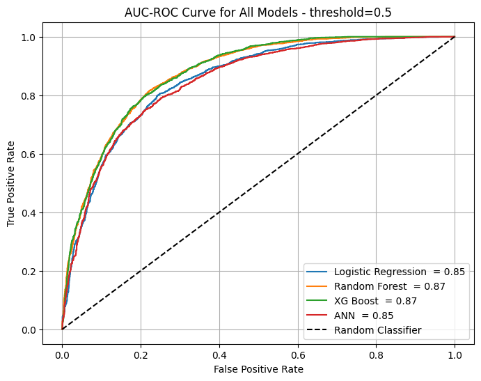

```
                     F1 Score  Precision  Recall  Accuracy  AUC-ROC
Logistic Regression      0.77       0.78    0.75      0.77     0.85
Random Forest            0.80       0.77    0.83      0.79     0.87
XG Boost                 0.80       0.77    0.84      0.79     0.87
ANN                      0.77       0.76    0.79      0.77     0.85
```

```python
model_analysis(threshold=0.5)
```

AUC - ROC Plot is a great way to determine the best model. It is the area under the curve for each model. The random classifier is 0.5 (Worst performing).

The above results were obtained using the standard threshold of 0.5. Overall, the Random Forest and XGBoost models performed well. However, it would be worthwhile to investigate their performance at different thresholds, such as 0.4 and 0.6. Since the dataset is imbalanced and our primary goal is to capture fraudulent transactions, achieving a high recall is crucial. At the same time, we aim to maintain a reasonable precision, along with high F1 scores and AUC-ROC values.

##### Threshold = 0.4

```python
auc_data= []
all_metrics= []
```

##### Logistic Regression

```
Best Params for Logistic Regression: {'C': 10, 'penalty': 'l2', 'solver': 'lbfgs'}
Confusion Matrix with 0.4
```

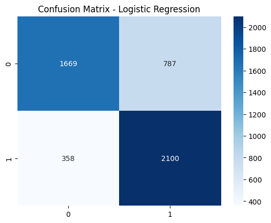

```
AUC-ROC Curve
```

```
   F1 Score  Precision  Recall  Accuracy  AUC-ROC
0      0.79       0.73    0.85      0.77     0.85
```

```python
run_logi(threshold=0.4)
```

[output not shown]

##### Random Forest

```
Best Params for Random Forest {'max_depth': None, 'min_samples_split': 2, 'n_estimators': 200}
Confusion Matrix with 0.4
```

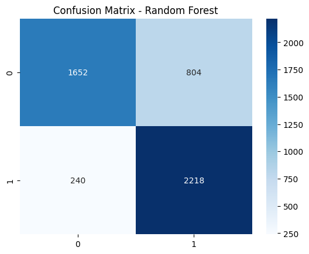

```
AUC-ROC Curve
```

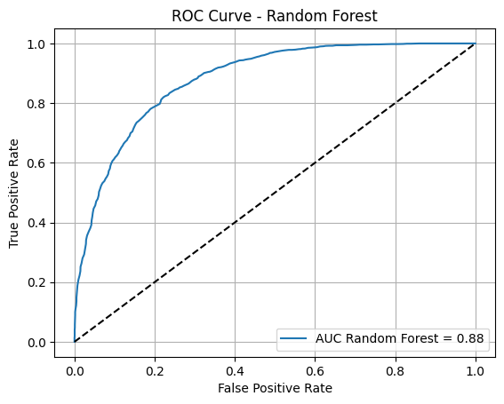

```
   F1 Score  Precision  Recall  Accuracy  AUC-ROC
0      0.81       0.73     0.9      0.79     0.88
```

```python
run_rf(threshold=0.4)
```

#### XGboost

[output not shown]

[output cut: 137 more lines]

[output not shown]

```
Best Params for XG-Boost {'learning_rate': 0.1, 'max_depth': 3, 'n_estimators': 100, 'subsample': 0.8}
Confusion Matrix with 0.4
```

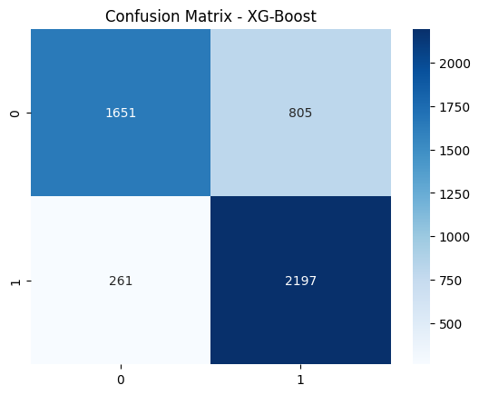

```
AUC-ROC Curve
```

```
   F1 Score  Precision  Recall  Accuracy  AUC-ROC
0       0.8       0.73    0.89      0.78     0.87
```

```python
run_xg(threshold=0.4)
```

[output not shown]

##### ANN

```
Fitting 3 folds for each of 16 candidates, totalling 48 fits
```

```
[CV] END batch_size=32, epochs=100, model__alpha=0.0001, model__hidden_layer_sizes=(64,), model__learning_rate_init=0.01; total time=  52.5s
[CV] END batch_size=32, epochs=100, model__alpha=0.0001, model__hidden_layer_sizes=(64,), model__learning_rate_init=0.01; total time=  52.6s
```

```
[CV] END batch_size=32, epochs=100, model__alpha=0.0001, model__hidden_layer_sizes=(64,), model__learning_rate_init=0.01; total time=  53.0s
[CV] END batch_size=32, epochs=100, model__alpha=0.0001, model__hidden_layer_sizes=(64,), model__learning_rate_init=0.001; total time=  53.1s
[CV] END batch_size=32, epochs=100, model__alpha=0.0001, model__hidden_layer_sizes=(64,), model__learning_rate_init=0.001; total time=  53.1s
```

```
[CV] END batch_size=32, epochs=100, model__alpha=0.0001, model__hidden_layer_sizes=(128,), model__learning_rate_init=0.001; total time=  53.4s
[CV] END batch_size=32, epochs=100, model__alpha=0.0001, model__hidden_layer_sizes=(128,), model__learning_rate_init=0.001; total time=  53.4s
[CV] END batch_size=32, epochs=100, model__alpha=0.0001, model__hidden_layer_sizes=(64,), model__learning_rate_init=0.001; total time=  53.5s
```

```
[CV] END batch_size=32, epochs=100, model__alpha=0.0001, model__hidden_layer_sizes=(128,), model__learning_rate_init=0.01; total time=  53.9s
```

```
[CV] END batch_size=32, epochs=100, model__alpha=0.0001, model__hidden_layer_sizes=(128,), model__learning_rate_init=0.001; total time=  54.6s
```

```
[CV] END batch_size=32, epochs=100, model__alpha=0.0001, model__hidden_layer_sizes=(128,), model__learning_rate_init=0.01; total time=  54.5s
[CV] END batch_size=32, epochs=100, model__alpha=0.0001, model__hidden_layer_sizes=(128,), model__learning_rate_init=0.01; total time=  54.6s
```

```
[CV] END batch_size=32, epochs=100, model__alpha=0.0001, model__hidden_layer_sizes=(64, 32), model__learning_rate_init=0.01; total time=  55.6s
```

```
[CV] END batch_size=32, epochs=100, model__alpha=0.0001, model__hidden_layer_sizes=(64, 32), model__learning_rate_init=0.001; total time=  56.3s
```

```
[CV] END batch_size=32, epochs=100, model__alpha=0.0001, model__hidden_layer_sizes=(64, 32), model__learning_rate_init=0.001; total time=  57.0s
[CV] END batch_size=32, epochs=100, model__alpha=0.0001, model__hidden_layer_sizes=(64, 32), model__learning_rate_init=0.001; total time=  56.8s
```

```
[CV] END batch_size=32, epochs=100, model__alpha=0.0001, model__hidden_layer_sizes=(64, 32), model__learning_rate_init=0.01; total time=  58.6s
```

```
[CV] END batch_size=32, epochs=100, model__alpha=0.0001, model__hidden_layer_sizes=(64, 32), model__learning_rate_init=0.01; total time=  58.6s
```

```
[CV] END batch_size=32, epochs=100, model__alpha=0.0001, model__hidden_layer_sizes=(16, 32, 32), model__learning_rate_init=0.001; total time=  58.9s
```

```
[CV] END batch_size=32, epochs=100, model__alpha=0.0001, model__hidden_layer_sizes=(16, 32, 32), model__learning_rate_init=0.001; total time=  59.0s
```

```
[CV] END batch_size=32, epochs=100, model__alpha=0.0001, model__hidden_layer_sizes=(16, 32, 32), model__learning_rate_init=0.001; total time=  59.5s
```

```
[CV] END batch_size=32, epochs=100, model__alpha=0.0001, model__hidden_layer_sizes=(16, 32, 32), model__learning_rate_init=0.01; total time=  59.7s
```

```
[CV] END batch_size=32, epochs=100, model__alpha=0.0001, model__hidden_layer_sizes=(16, 32, 32), model__learning_rate_init=0.01; total time=  59.7s
```

```
[CV] END batch_size=32, epochs=100, model__alpha=0.0001, model__hidden_layer_sizes=(16, 32, 32), model__learning_rate_init=0.01; total time= 1.0min
```

```
[CV] END batch_size=32, epochs=100, model__alpha=0.001, model__hidden_layer_sizes=(64,), model__learning_rate_init=0.001; total time=  53.4s
```

```
[CV] END batch_size=32, epochs=100, model__alpha=0.001, model__hidden_layer_sizes=(64,), model__learning_rate_init=0.001; total time=  53.7s
```

```
[CV] END batch_size=32, epochs=100, model__alpha=0.001, model__hidden_layer_sizes=(64,), model__learning_rate_init=0.001; total time=  53.8s
```

```
[CV] END batch_size=32, epochs=100, model__alpha=0.001, model__hidden_layer_sizes=(64,), model__learning_rate_init=0.01; total time=  54.1s
```

```
[CV] END batch_size=32, epochs=100, model__alpha=0.001, model__hidden_layer_sizes=(64,), model__learning_rate_init=0.01; total time=  53.0s
```

```
[CV] END batch_size=32, epochs=100, model__alpha=0.001, model__hidden_layer_sizes=(64,), model__learning_rate_init=0.01; total time=  53.7s
```

```
[CV] END batch_size=32, epochs=100, model__alpha=0.001, model__hidden_layer_sizes=(128,), model__learning_rate_init=0.001; total time=  53.4s
```

```
[CV] END batch_size=32, epochs=100, model__alpha=0.001, model__hidden_layer_sizes=(128,), model__learning_rate_init=0.001; total time=  55.1s
```

```
[CV] END batch_size=32, epochs=100, model__alpha=0.001, model__hidden_layer_sizes=(128,), model__learning_rate_init=0.01; total time=  54.5s
[CV] END batch_size=32, epochs=100, model__alpha=0.001, model__hidden_layer_sizes=(128,), model__learning_rate_init=0.001; total time=  55.3s
```

```
[CV] END batch_size=32, epochs=100, model__alpha=0.001, model__hidden_layer_sizes=(128,), model__learning_rate_init=0.01; total time=  54.2s
```

```
[CV] END batch_size=32, epochs=100, model__alpha=0.001, model__hidden_layer_sizes=(128,), model__learning_rate_init=0.01; total time=  54.3s
```

```
[CV] END batch_size=32, epochs=100, model__alpha=0.001, model__hidden_layer_sizes=(64, 32), model__learning_rate_init=0.001; total time=  57.1s
```

```
[CV] END batch_size=32, epochs=100, model__alpha=0.001, model__hidden_layer_sizes=(64, 32), model__learning_rate_init=0.001; total time=  57.0s
```

```
[CV] END batch_size=32, epochs=100, model__alpha=0.001, model__hidden_layer_sizes=(64, 32), model__learning_rate_init=0.001; total time=  56.8s
```

```
[CV] END batch_size=32, epochs=100, model__alpha=0.001, model__hidden_layer_sizes=(64, 32), model__learning_rate_init=0.01; total time=  57.1s
```

[output not shown]

```
Best Params ANN: {'batch_size': 32, 'epochs': 100, 'model__alpha': 0.0001, 'model__hidden_layer_sizes': (16, 32, 32), 'model__learning_rate_init': 0.01}
154/154 ━━━━━━━━━━━━━━━━━━━━ 0s 394us/step
Confusion Matrix with 0.4
```

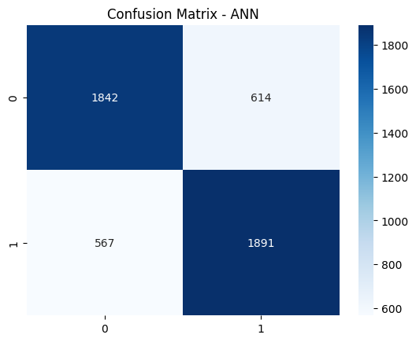

```
AUC-ROC Curve
```

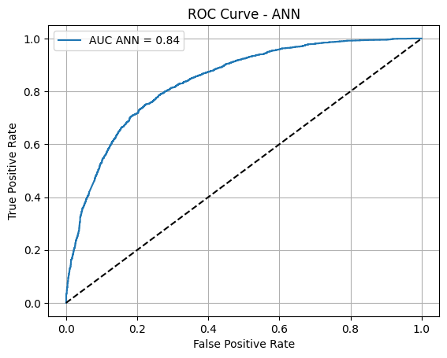

```
   F1 Score  Precision  Recall  Accuracy  AUC-ROC
0      0.76       0.75    0.77      0.76     0.84
```

```python
run_ann(threshold=0.4)
```

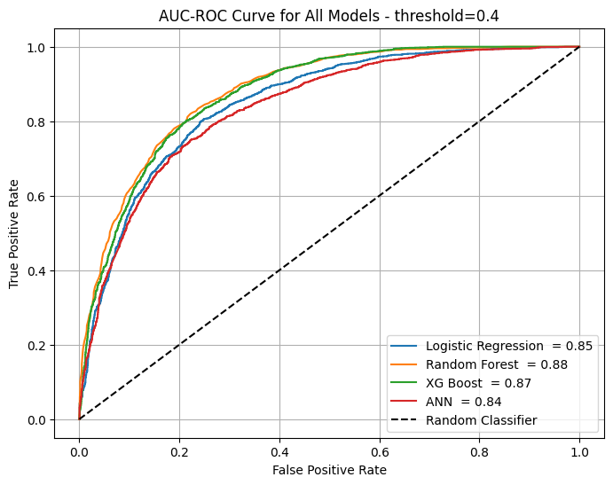

```
                     F1 Score  Precision  Recall  Accuracy  AUC-ROC
Logistic Regression      0.79       0.73    0.85      0.77     0.85
Random Forest            0.81       0.73    0.90      0.79     0.88
XG Boost                 0.80       0.73    0.89      0.78     0.87
ANN                      0.76       0.75    0.77      0.76     0.84
```

```python
model_analysis(threshold=0.4)
```

Result (Thrershold = 0.4)

- Random Forest is the best performer with highest AUC-ROC (0.88), having high recall (0.9) - Captures 90% of fraud cases, it is critical for imbalance data
- Trade-off : Decline in precision (0.73) compared to (0.77) in case of threshold = 0.5
- XGBoost also performed decent similar to random forest
- Logistic Regressiona and ANN lags in performance compared to Random Forest and XGBoost
- Overall, for fraud transaction detection (High recall needed) -> Random Forest at threshold = 0.4 is optimal

##### Threshold = 0.6

```python
auc_data= []
all_metrics= []
```

##### Logistic Regression

```
Best Params for Logistic Regression: {'C': 10, 'penalty': 'l2', 'solver': 'lbfgs'}
Confusion Matrix with 0.6
```

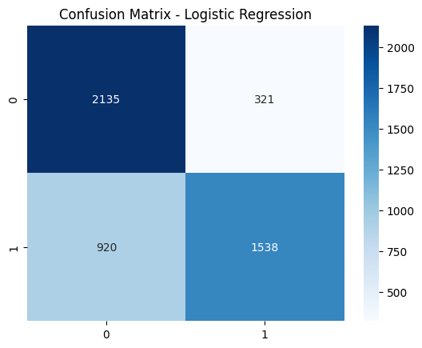

```
AUC-ROC Curve
```

```
   F1 Score  Precision  Recall  Accuracy  AUC-ROC
0      0.71       0.83    0.63      0.75     0.85
```

```python
run_logi(threshold=0.6)
```

[output not shown]

##### Random Forest

```
Best Params for Random Forest {'max_depth': 10, 'min_samples_split': 2, 'n_estimators': 200}
Confusion Matrix with 0.6
```

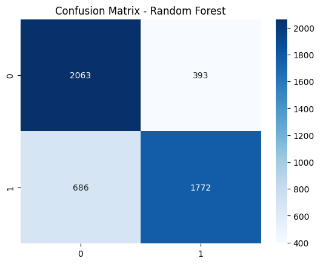

```
AUC-ROC Curve
```

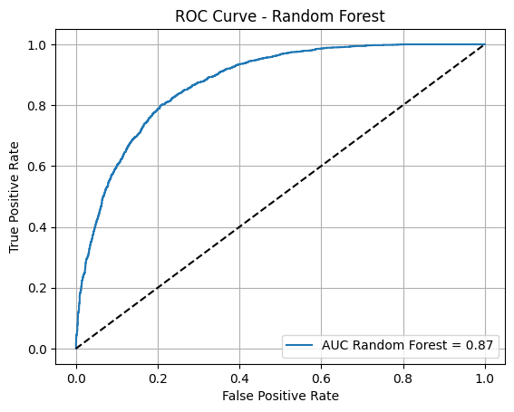

```
   F1 Score  Precision  Recall  Accuracy  AUC-ROC
0      0.77       0.82    0.72      0.78     0.87
```

```python
run_rf(threshold=0.6)
```

#### XGBoost

[output not shown]

[output cut: 137 more lines]

[output not shown]

```
Best Params for XG-Boost {'learning_rate': 0.1, 'max_depth': 3, 'n_estimators': 100, 'subsample': 0.8}
Confusion Matrix with 0.6
```

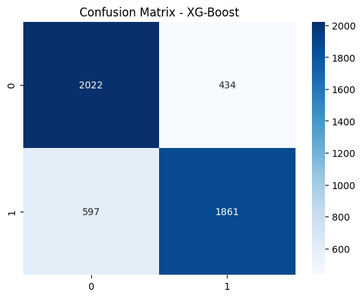

```
AUC-ROC Curve
```

```
   F1 Score  Precision  Recall  Accuracy  AUC-ROC
0      0.78       0.81    0.76      0.79     0.87
```

```python
run_xg(threshold=0.6)
```

[output not shown]

##### ANN

```
Fitting 3 folds for each of 16 candidates, totalling 48 fits
```

```
[CV] END batch_size=32, epochs=100, model__alpha=0.0001, model__hidden_layer_sizes=(64,), model__learning_rate_init=0.01; total time=  52.7s
```

```
[CV] END batch_size=32, epochs=100, model__alpha=0.0001, model__hidden_layer_sizes=(128,), model__learning_rate_init=0.001; total time=  53.0s
[CV] END batch_size=32, epochs=100, model__alpha=0.0001, model__hidden_layer_sizes=(64,), model__learning_rate_init=0.01; total time=  53.2s
```

```
[CV] END batch_size=32, epochs=100, model__alpha=0.0001, model__hidden_layer_sizes=(64,), model__learning_rate_init=0.001; total time=  53.4s
[CV] END batch_size=32, epochs=100, model__alpha=0.0001, model__hidden_layer_sizes=(64,), model__learning_rate_init=0.01; total time=  53.4s
[CV] END batch_size=32, epochs=100, model__alpha=0.0001, model__hidden_layer_sizes=(64,), model__learning_rate_init=0.001; total time=  53.4s
[CV] END batch_size=32, epochs=100, model__alpha=0.0001, model__hidden_layer_sizes=(64,), model__learning_rate_init=0.001; total time=  53.5s
```

```
[CV] END batch_size=32, epochs=100, model__alpha=0.0001, model__hidden_layer_sizes=(128,), model__learning_rate_init=0.001; total time=  54.2s
```

```
[CV] END batch_size=32, epochs=100, model__alpha=0.0001, model__hidden_layer_sizes=(128,), model__learning_rate_init=0.01; total time=  52.9s
```

```
[CV] END batch_size=32, epochs=100, model__alpha=0.0001, model__hidden_layer_sizes=(128,), model__learning_rate_init=0.001; total time=  53.9s
```

```
[CV] END batch_size=32, epochs=100, model__alpha=0.0001, model__hidden_layer_sizes=(128,), model__learning_rate_init=0.01; total time=  53.9s
```

```
[CV] END batch_size=32, epochs=100, model__alpha=0.0001, model__hidden_layer_sizes=(128,), model__learning_rate_init=0.01; total time=  54.9s
```

```
[CV] END batch_size=32, epochs=100, model__alpha=0.0001, model__hidden_layer_sizes=(64, 32), model__learning_rate_init=0.001; total time=  56.1s
[CV] END batch_size=32, epochs=100, model__alpha=0.0001, model__hidden_layer_sizes=(64, 32), model__learning_rate_init=0.001; total time=  56.0s
```

```
[CV] END batch_size=32, epochs=100, model__alpha=0.0001, model__hidden_layer_sizes=(64, 32), model__learning_rate_init=0.001; total time=  56.2s
```

```
[CV] END batch_size=32, epochs=100, model__alpha=0.0001, model__hidden_layer_sizes=(64, 32), model__learning_rate_init=0.01; total time=  56.5s
```

```
[CV] END batch_size=32, epochs=100, model__alpha=0.0001, model__hidden_layer_sizes=(64, 32), model__learning_rate_init=0.01; total time=  56.9s
```

```
[CV] END batch_size=32, epochs=100, model__alpha=0.0001, model__hidden_layer_sizes=(64, 32), model__learning_rate_init=0.01; total time=  56.9s
```

```
[CV] END batch_size=32, epochs=100, model__alpha=0.0001, model__hidden_layer_sizes=(16, 32, 32), model__learning_rate_init=0.001; total time=  58.8s
[CV] END batch_size=32, epochs=100, model__alpha=0.0001, model__hidden_layer_sizes=(16, 32, 32), model__learning_rate_init=0.001; total time=  57.9s
```

```
[CV] END batch_size=32, epochs=100, model__alpha=0.0001, model__hidden_layer_sizes=(16, 32, 32), model__learning_rate_init=0.01; total time=  57.9s
[CV] END batch_size=32, epochs=100, model__alpha=0.0001, model__hidden_layer_sizes=(16, 32, 32), model__learning_rate_init=0.01; total time=  58.3s
```

```
[CV] END batch_size=32, epochs=100, model__alpha=0.0001, model__hidden_layer_sizes=(16, 32, 32), model__learning_rate_init=0.001; total time=  58.4s
```

```
[CV] END batch_size=32, epochs=100, model__alpha=0.0001, model__hidden_layer_sizes=(16, 32, 32), model__learning_rate_init=0.01; total time=  58.9s
```

```
[CV] END batch_size=32, epochs=100, model__alpha=0.001, model__hidden_layer_sizes=(64,), model__learning_rate_init=0.001; total time=  53.1s
```

```
[CV] END batch_size=32, epochs=100, model__alpha=0.001, model__hidden_layer_sizes=(64,), model__learning_rate_init=0.001; total time=  53.8s
```

```
[CV] END batch_size=32, epochs=100, model__alpha=0.001, model__hidden_layer_sizes=(64,), model__learning_rate_init=0.01; total time=  53.9s
```

```
[CV] END batch_size=32, epochs=100, model__alpha=0.001, model__hidden_layer_sizes=(64,), model__learning_rate_init=0.001; total time=  54.4s
```

```
[CV] END batch_size=32, epochs=100, model__alpha=0.001, model__hidden_layer_sizes=(64,), model__learning_rate_init=0.01; total time=  52.9s
```

```
[CV] END batch_size=32, epochs=100, model__alpha=0.001, model__hidden_layer_sizes=(128,), model__learning_rate_init=0.001; total time=  53.4s
[CV] END batch_size=32, epochs=100, model__alpha=0.001, model__hidden_layer_sizes=(64,), model__learning_rate_init=0.01; total time=  53.6s
```

```
[CV] END batch_size=32, epochs=100, model__alpha=0.001, model__hidden_layer_sizes=(128,), model__learning_rate_init=0.001; total time=  53.9s
```

```
[CV] END batch_size=32, epochs=100, model__alpha=0.001, model__hidden_layer_sizes=(128,), model__learning_rate_init=0.001; total time=  54.9s
```

```
[CV] END batch_size=32, epochs=100, model__alpha=0.001, model__hidden_layer_sizes=(128,), model__learning_rate_init=0.01; total time=  55.0s
```

```
[CV] END batch_size=32, epochs=100, model__alpha=0.001, model__hidden_layer_sizes=(128,), model__learning_rate_init=0.01; total time=  55.9s
```

```
[CV] END batch_size=32, epochs=100, model__alpha=0.001, model__hidden_layer_sizes=(128,), model__learning_rate_init=0.01; total time=  56.7s
```

```
[CV] END batch_size=32, epochs=100, model__alpha=0.001, model__hidden_layer_sizes=(64, 32), model__learning_rate_init=0.001; total time=  58.0s
[CV] END batch_size=32, epochs=100, model__alpha=0.001, model__hidden_layer_sizes=(64, 32), model__learning_rate_init=0.001; total time=  57.2s
```

```
[CV] END batch_size=32, epochs=100, model__alpha=0.001, model__hidden_layer_sizes=(64, 32), model__learning_rate_init=0.001; total time=  59.3s
```

```
[CV] END batch_size=32, epochs=100, model__alpha=0.001, model__hidden_layer_sizes=(64, 32), model__learning_rate_init=0.01; total time=  58.9s
```

[output not shown]

```
Best Params ANN: {'batch_size': 32, 'epochs': 100, 'model__alpha': 0.001, 'model__hidden_layer_sizes': (64, 32), 'model__learning_rate_init': 0.001}
154/154 ━━━━━━━━━━━━━━━━━━━━ 0s 403us/step
Confusion Matrix with 0.6
```

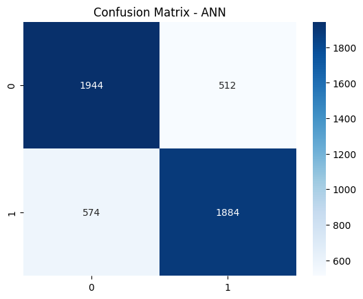

```
AUC-ROC Curve
```

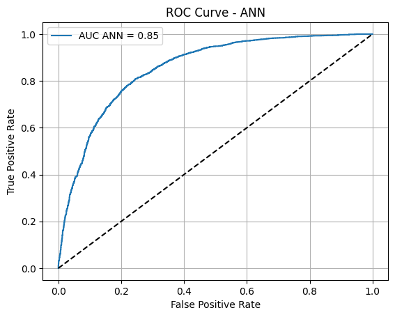

```
   F1 Score  Precision  Recall  Accuracy  AUC-ROC
0      0.78       0.79    0.77      0.78     0.85
```

```python
run_ann(threshold=0.6)
```

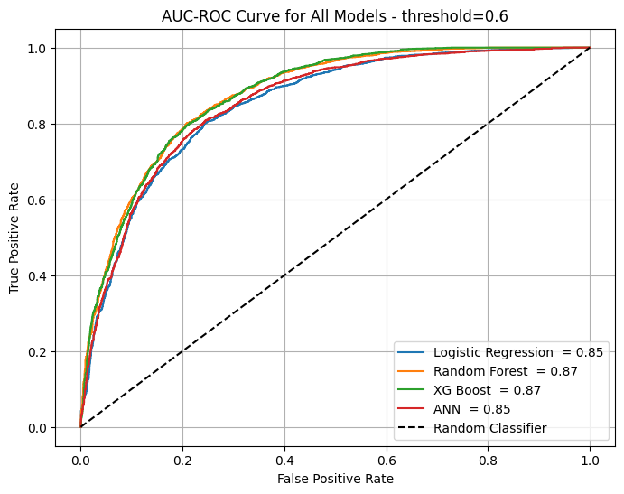

```
                     F1 Score  Precision  Recall  Accuracy  AUC-ROC
Logistic Regression      0.71       0.83    0.63      0.75     0.85
Random Forest            0.77       0.82    0.72      0.78     0.87
XG Boost                 0.78       0.81    0.76      0.79     0.87
ANN                      0.78       0.79    0.77      0.78     0.85
```

```python
model_analysis(threshold=0.6)
```

In case of threshold = 0.6, precision is more than recall in all models

#### Feature Importance

```python
## load processor
threshold = 0.4
model_selected = "random_forest_model"
with open("pickle_files/preprocessing_pipeline.pkl", "rb") as f:
    preprocessor = pickle.load(f)
## load random forest model
with open(f"pickle_files/{threshold}_{model_selected}.pkl", "rb") as f:
    model = pickle.load(f)


def get_feature_names(preprocessor):
    output_features = []
    for name, transformer, cols in preprocessor.transformers_:
        last_step = (
            transformer.steps[-1][1]
            if isinstance(transformer, Pipeline)
            else transformer
        )
        names = getattr(last_step, "get_feature_names_out", lambda x: x)(cols)
        output_features.extend(names)
    return output_features


process = preprocessor.fit_transform(X, y)
feature_names = get_feature_names(preprocessor)
## Update the high card colm in feature name with proper name

updated_feature_names = []

j = 0
for name in feature_names:
    if isinstance(name, (int, np.integer)):
        updated_feature_names.append(high_cardinality_columns[j])
        j += 1
    else:
        updated_feature_names.append(name)
```

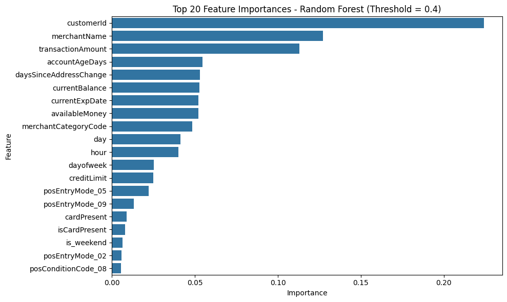

```python
importances = model.feature_importances_
feat_imp_df = pd.DataFrame(
    {"Feature": updated_feature_names, "Importance": importances}
).sort_values(by="Importance", ascending=False)
## Plot top N features
top_n = 20
plt.figure(figsize=(10, 6))
sns.barplot(x="Importance", y="Feature", data=feat_imp_df.head(top_n))
plt.title(f"Top {top_n} Feature Importances - Random Forest (Threshold = 0.4)")
plt.tight_layout()
plt.show()
```

- Customer ID is the most important feature in determining a fraudulent transaction, with a feature importance score exceeding 0.2.
- Merchant Name and Transaction Amount are also highly significant, with scores around 0.13 and 0.11, respectively.
- Features such as Account Age, Current Balance, Available Money, and Time of Transaction exhibit moderate importance.
- All other features contribute relatively lower importance to the model’s decision-making Conclusion : Customer ID, Merchant Name and Transaction Amount are the most critical feature for identifying fradulant transcation

## Conclusion

The transactional dataset was provided with fields like Mercant information, transaction details, time , customerid , acoount, etc. The objective was to perform analysis and build a predictive model to determinne wheather a transaction is fradulant

Overall, the Random Forest (threshlod = 0.4) with high recall and resonably high previous is the best choice in detecting in Fradulent transactions. The model has AUC-ROC (0.88) , Recall (0.90) , Precison (0.73) and F1 (0.81) Feature Importance: Customer ID, Merchant Name and Transaction Amount are the most critical feature for identifying fradulant transcation

#### Additional Work - Further enhancement

- Handle Class Imbalance with SMOTE : comparing the result based on it's performance against random downsampling approcah and tradeoff in precision, recall and generalization
- Modular Infernece Pipeline : Clean and usable pipeline (Data Ingestion -> Data Cleaning and Feature Engineering -> Fraud Prediction using Trained Model) [Most of the code in the current Jupyter Notebook - Defined using classes and function and will be quick to translate into Pipline - Sample code in the end]
- Dockerization : Create a docker image and handing dependencies
- AB Experimentation : Setting up a AB experimentation before the mass release and providing to a small section of users
- Logger and Debugging : Adding logger information for debugging purposed - (Model Prediction, Data Issues, etc)
- Model in Produiction: continous monitoring on performane of online metric and set up alerting threshold based on metric performance

##### Model Retraining

- Option 1 - Fully retrain the current model with updated weights
- Option 2 - Output of last layers of complex models (ANN , Ensemble) as features and feed them into Logistic Regression for fast retraing and Inference

##### (Additional) Model with new Data

Sample code is provided to run the model with new data

```python
# import pickle
# import pandas as pd

# class fraud_transcation:
#     ## Load preprocessing pipeline
#     with open("pickle_files/preprocessing_pipeline.pkl", "rb") as f:
#         preprocessor = pickle.load(f)
#     ## Load trained model
#     with open("pickle_files/0.4_random_forest_model.pkl", "rb") as f:
#         model = pickle.load(f)

#     def load(self, file_path):
#         data_load = pd.read_json(file_path, lines=True)
#         new_transaction = data.replace("", np.nan, inplace=True)
#         return new_transaction

#     def process_data(self, new_transaction):
#         df = new_transaction.copy()
#         df["hour"] = df["transactionDateTime"].dt.hour
#         df["dayofweek"] = df["transactionDateTime"].dt.dayofweek
#         df["day"] = df["transactionDateTime"].dt.day
#         df["is_weekend"] = df["dayofweek"].isin([5, 6]).astype(int)

#         df["accountAgeDays"] = (
#             df["transactionDateTime"] - df["accountOpenDate"]
#         ).dt.days
#         df["daysSinceAddressChange"] = (
#             df["transactionDateTime"] - df["dateOfLastAddressChange"]
#         ).dt.days

#         df["cvv_mismatch"] = (df["cardCVV"] != df["enteredCVV"]).astype(int)
#         df["isCardPresent"] = df["cardPresent"].astype(int)
#         df["isExpMatch"] = df["expirationDateKeyInMatch"].astype(int)
#         df["cardPresent"] = df["cardPresent"].astype(int)

#         drop_columns = [
#             "accountNumber",
#             "transactionDateTime",
#             "accountOpenDate",
#             "dateOfLastAddressChange",
#             "cardCVV",
#             "enteredCVV",
#             "cardLast4Digits",
#             "echoBuffer",
#             "expirationDateKeyInMatch",
#             "merchantCity",
#             "merchantState",
#             "merchantZip",
#             "posOnPremises",
#             "recurringAuthInd",
#         ]

#         df.drop(columns=drop_columns, inplace=True, errors="ignore")
#         return df

#     def predict_result(self, df):
#         X_new = preprocessor.transform(df.drop(columns=["isFraud"], errors="ignore"))
#         prediction = model.predict(X_new)
#         proba = model.predict_proba(X_new)[:, 1]

#         print("Transcation is Fraud :", True if prediction[0] == 1 else 0)
#         print("Fraudulant transcation Probability:", proba[0])
```

```python
# fraud = fraud_transcation()
# new_transaction = fraud.load('data/new_transcation.txt')
# df = fraud.process_data(new_transaction)
# fraud.predict_result(df)
```